# Install and load the required packages:

### Install and load the required packages:

```r
r_repos <- "http://cran.rstudio.com/"
install.packages("RCurl", repos = r_repos)
install.packages("rmarkdown", repos = r_repos)
install.packages("data.table", repos = r_repos)
```

```r
install.packages("ggplot2", repos = r_repos)
install.packages("lattice", repos = r_repos)
library(RCurl)
library(markdown)
library(data.table)
```

### 1) Get and clean the activity data:

```r
temp <- tempfile()
gitHubUrl <- "https://github.com/dholtz/RepData_PeerAssessment1/blob/master/activity.zip?raw=true"
download.file(gitHubUrl, temp)
activityMonitoringData <- read.csv(unz(temp, "activity.csv"))
unlink(temp)
cleanActivityMonitoringData <- na.omit(activityMonitoringData)
```

### 2) Total Number of Steps Taken Each Day

#### 2a) Total Number of Steps taken per Day

```r
stepsPerDay <- aggregate(steps ~ date, cleanActivityMonitoringData, sum)
```

#### 2b) Total Number of Steps taken each Day (Historgram)

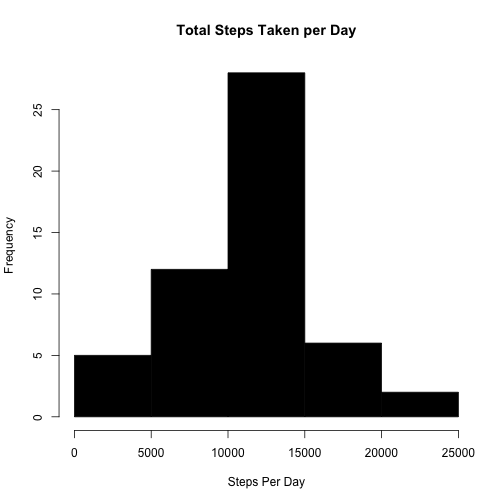

```r
hist(stepsPerDay$steps, main = "Total Steps Taken per Day", xlab = "Steps Per Day",
    col = 1)
```

#### 2c) Mean and Median of total number of steps taken per day

```r
mean(stepsPerDay$steps)
```

```
## [1] 10766.19
```

```r
median(stepsPerDay$steps)
```

```
## [1] 10765
```

### 3) What is the average daily activity pattern?

```r
intervalOfStepsAverage <- aggregate(steps ~ interval, cleanActivityMonitoringData,
    mean)
```

#### 3a) Time Series plot

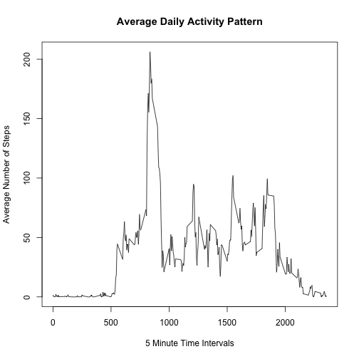

```r
plot(intervalOfStepsAverage$interval, intervalOfStepsAverage$steps, type = "l",
    main = "Average Daily Activity Pattern", xlab = "5 Minute Time Intervals",
    ylab = "Average Number of Steps")
```

### 3b) 5-minute interval, on average across all days, contains the maximum number of steps?

```r
maxIntervalSteps <- intervalOfStepsAverage[which.max(intervalOfStepsAverage$steps),
    ]
```

#### -The interval, 835 contained, 206.1698113 steps.

### 4) Strategy for imputing Missing Data

#### 4a) Total number of missing values in the dataset (the total number of rows with NAs)

```r
totalNumNAs <- colSums(is.na(activityMonitoringData))
```

##### - There are 2304, NA's in the steps, 0, NA's in the date,

##### and 0, NA's in the interval.

### 5) Total Number of Steps Taken Each Day, AFTER missing values are imputed

#### 5a) Fill in the missing values with the mean value for the 5-minute interval

```r
mean5MinIntervalFn <- function(steps, interval) {
    filled <- NA
    if (!is.na(steps)) {
        filled <- c(steps)
    } else {
        filled <- intervalOfStepsAverage[intervalOfStepsAverage$interval ==
            interval, "steps"]
    }
    filled
}

missingValuesFilled <- activityMonitoringData
missingValuesFilled$steps <- mapply(mean5MinIntervalFn, missingValuesFilled$steps,
    missingValuesFilled$interval)
missingFilledIntervalOfStepsAverage <- aggregate(steps ~ date, missingValuesFilled,
    sum)
```

```r
# Sanity check that all NAs are removed from original data set
postNAFillCheck <- colSums(is.na(missingValuesFilled))
```

##### - There are 0, 0, 0, NA's in the filled data set.

#### 5b) Compare the original steps taken each day with NA filled in data.

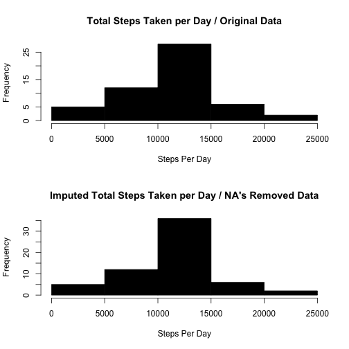

```r
par(mfrow = c(2, 1))

hist(stepsPerDay$steps, main = "Total Steps Taken per Day / Original Data",
    xlab = "Steps Per Day", col = 1)
hist(missingFilledIntervalOfStepsAverage$steps, main = "Imputed Total Steps Taken per Day / NA's Removed Data",
    xlab = "Steps Per Day", col = 1)
```

```r
mean(stepsPerDay$steps)
```

```
## [1] 10766.19
```

```r
median(missingFilledIntervalOfStepsAverage$steps)
```

```
## [1] 10766.19
```

### 6) Comparing the Average Number of Steps taken per 5-minute Interval Across Weekdays and Weekends

#### 6a) Create factor variable in the 'filled' data set with two levels, “weekday” and “weekend” indicating

#### whether a given date is a weekday or weekend day.

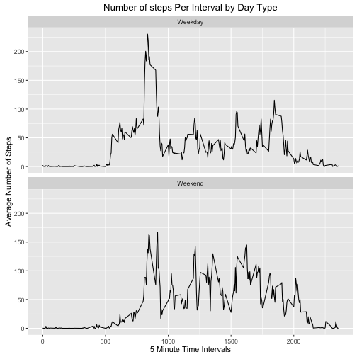

```r
weekDayOrWeekEnd <- function(strDate) {
    w <- NA
    val <- weekdays(as.Date(strDate, "%Y-%m-%d"))
    if (!(val == "Saturday" || val == "Sunday")) {
        w <- "Weekday"
    } else {
        w <- "Weekend"
    }
    w
}

missingValuesFilled$typeOfDay <- as.factor(sapply(missingValuesFilled$date,
    weekDayOrWeekEnd))

imputedStepsPerDay <- aggregate(steps ~ interval + typeOfDay, missingValuesFilled,
    mean)

# load ggplot 2 library
library(ggplot2)

qplot(interval, steps, data = imputedStepsPerDay, geom = c("line"), xlab = "5 Minute Time Intervals",
    ylab = "Average Number of Steps", main = "Number of steps Per Interval by Day Type") +
    facet_wrap(~typeOfDay, ncol = 1)
```

#### - This can be more easily visualized by showing the data on a single plot.

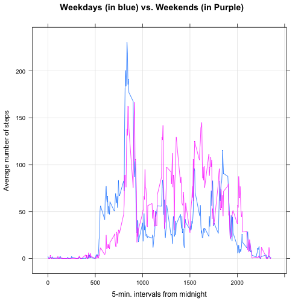

```r
library(lattice)

xyplot(steps ~ interval, data = imputedStepsPerDay, groups = imputedStepsPerDay$typeOfDay,
    type = "l", grid = T, ylab = "Average number of steps", xlab = "5-min. intervals from midnight",
    main = "Weekdays (in blue) vs. Weekends (in Purple)")
```